# Projet Mixture model : USPS

#Binome: - Wacim BELAHCEL - Imad Oualid KACIMI

```r
library(R.matlab)
library(Factoshiny)
library(NbClust)
library(Rmixmod)
library(mclust)
library(clusterSim)
library(aricode)
library(h2o)
library(Rtsne)
library(tidyverse)
```

# Q1 : Introduction table de donnée

USPS ( US Post Office Zip Code ) est un dataset contenant des images de chiffres manuscrits de taile 16x16, pour un total donc de 256 variable représentant chacun un pixel noir et blanc de l’image.

```r
USPS = readMat(con="C:\\Users\\GIGABYTE\\Downloads\\DATA_MATLAB - Projet-master-MLDS\\DATA_MATLAB - Projet-master-MLDS\\USPS.mat")
```

```r
y_data = as.data.frame(USPS$y)
x_data = as.data.frame(USPS$X)
#x_test_data = as.data.frame(mnist$testX)
#y_test_data = as.data.frame(mnist$testY)
```

```r
x_data$y<-as.factor(t(y_data))

x_data <- x_data[!duplicated(x_data[,1:240]), ]
y_data <- as.data.frame(x_data$y)
```

# Q2: ACP

Depuis le graph des individus, on remarque que les classes sont trop mélangé et il est difficile de les séparer.Lorsque l’on représente uniquement les modalité de la variable cible y, on peut voir que les individu des classes y_2 et y_1 contribuent fortement à la creation de l’axe 1 alors que les individidus de la classes y_7 et y_8 contribuent à la creation de l’axe 2.

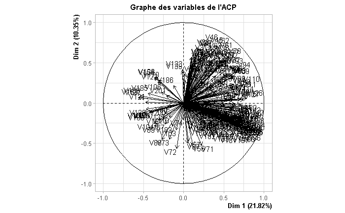

```r
res.PCA<-PCA(x_data,quali.sup=c(257),graph=FALSE)
plot.PCA(res.PCA,choix='var',title="Graphe des variables de l'ACP")
```

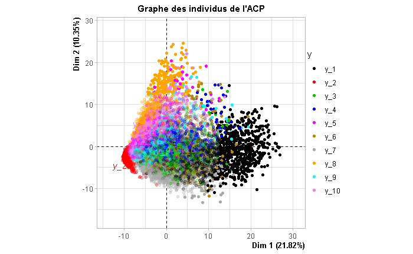

```r
plot.PCA(res.PCA,invisible=c('ind.sup'),select='contrib  1035',habillage=257,title="Graphe des individus de l'ACP",label =c('quali'))
```

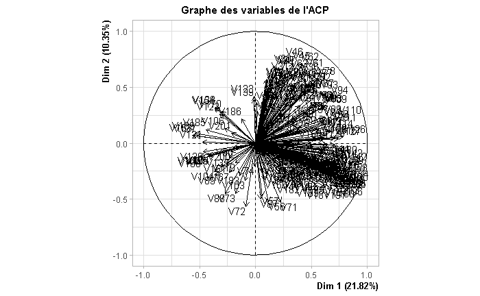

```r
res.PCA<-PCA(x_data,quali.sup=c(257),graph=FALSE)
plot.PCA(res.PCA,choix='var',title="Graphe des variables de l'ACP")
```

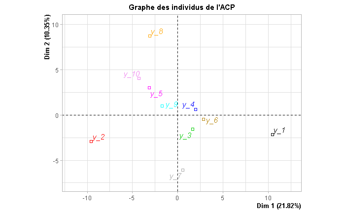

```r
plot.PCA(res.PCA,invisible=c('ind','ind.sup'),select='contrib  1035',habillage=257,title="Graphe des individus de l'ACP",label =c('quali'))
```

# Q4: Clustering Kmean / CAH

La plus part des algorithme ne trouvent que 2 classes en tant que nombre optimal lorsque nous appliquons un clustering, nous pouvons donc proposer 2 classes dans ce cas la, ce qui est tres loin du nombre de classe original.

```r
res_cah_ward <-NbClust(x_data[,1:256], distance = "euclidean", min.nc=2, max.nc=10, method = "ward.D2",
index = "ch")
res_cah_average<-NbClust(x_data[,1:256], distance = "euclidean", min.nc=2, max.nc=10, method = "average",
index = "ch")
res_cah_complete <-NbClust(x_data[,1:256], distance = "euclidean", min.nc=2, max.nc=10, method = "complete",
index = "ch")
res_cah_single <-NbClust(x_data[,1:256], distance = "euclidean", min.nc=2, max.nc=10, method = "single",
index = "ch")
res_cah_kmeans <-NbClust(x_data[,1:256], distance = "euclidean", min.nc=2, max.nc=10, method = "kmeans",
index = "ch")
```

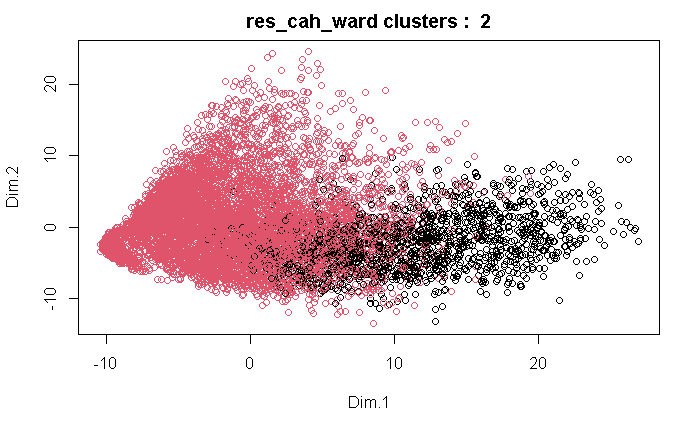

```r
plot(res.PCA$ind$coord,col=res_cah_ward$Best.partition, main = paste("res_cah_ward clusters : ",length(unique(res_cah_ward$Best.partition))))
```

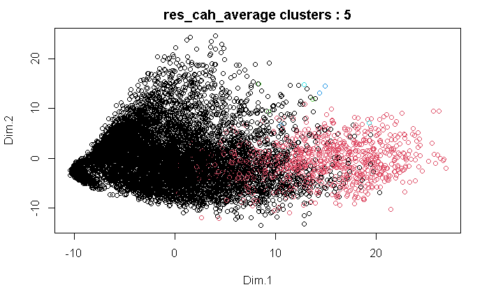

```r
plot(res.PCA$ind$coord,col=res_cah_average$Best.partition, main = paste("res_cah_average clusters :",length(unique(res_cah_average$Best.partition))))
```

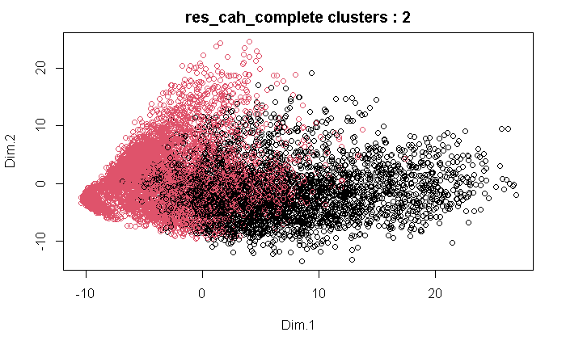

```r
plot(res.PCA$ind$coord,col=res_cah_complete$Best.partition,  main = paste("res_cah_complete clusters :",length(unique(res_cah_complete$Best.partition))))
```

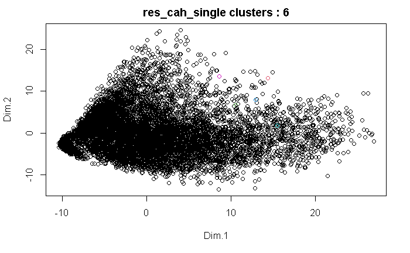

```r
plot(res.PCA$ind$coord,col=res_cah_single$Best.partition, main = paste("res_cah_single clusters :",length(unique(res_cah_single$Best.partition))))
```

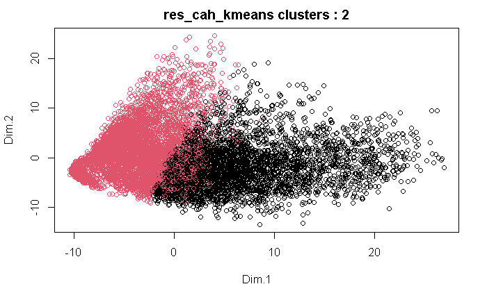

```r
plot(res.PCA$ind$coord,col=res_cah_kmeans$Best.partition, main = paste("res_cah_kmeans clusters :",length(unique(res_cah_kmeans$Best.partition))))
```

# Q5 : HCPC

En observant le graph de l’inertie, on peut remarquer que nous avons un premier coude au niveau de la 2 éme barre ainsi qu’un 2 éme coude au niveau de la 4éme barre, nous pouvons donc proposer 2 ou 4 clusters, 4 se rapprochant plus du nombre de classes original.

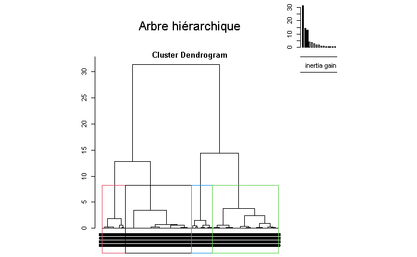

```r
res.PCA<-PCA(x_data,ncp=2,quali.sup=c(257),graph=FALSE)
res.HCPC<-HCPC(res.PCA,nb.clust=4,consol=FALSE,graph=FALSE)
plot.HCPC(res.HCPC,choice='tree',title='Arbre hiérarchique')
```

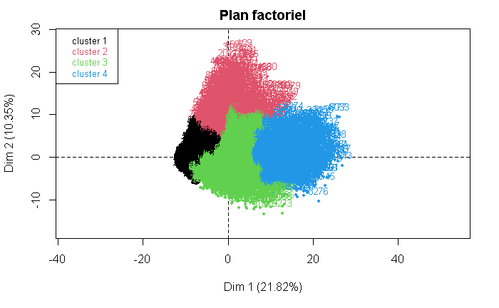

```r
plot.HCPC(res.HCPC,choice='map',draw.tree=FALSE,title='Plan factoriel')
```

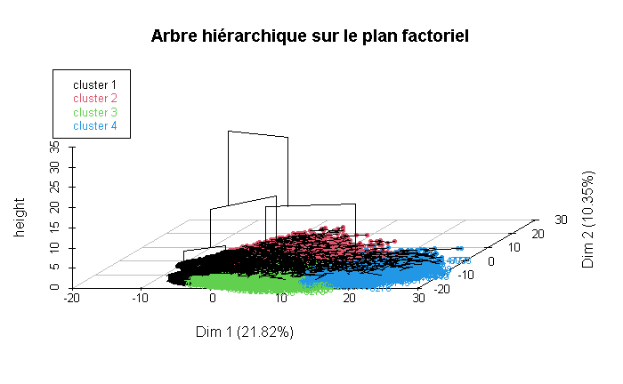

```r
plot.HCPC(res.HCPC,choice='3D.map',ind.names=TRUE,centers.plot=FALSE,angle=60,title='Arbre hiérarchique sur le plan factoriel')
```

# Q6 : comparaison avec HCPC

```r
table(as.vector(res.HCPC$data.clust[,"clust"]),as.vector(res_cah_ward$Best.partition))
```

```
       1    2
  1    6 3472
  2    5 1217
  3  606 2869
  4  921  202
```

```r
table(as.vector(res.HCPC$data.clust[,"clust"]),as.vector(res_cah_kmeans$Best.partition))
```

```
       1    2
  1   11 3467
  2  129 1093
  3 2406 1069
  4 1123    0
```

```r
table(as.vector(res.HCPC$data.clust[,"clust"]),as.vector(res_cah_complete$Best.partition))
```

```
       1    2
  1  250 3228
  2  222 1000
  3 2100 1375
  4 1092   31
```

```r
table(as.vector(res.HCPC$data.clust[,"clust"]),as.vector(res_cah_single$Best.partition))
```

```
       1    2    3    4    5    6
  1 3478    0    0    0    0    0
  2 1220    1    0    0    0    1
  3 3475    0    0    0    0    0
  4 1120    0    1    1    1    0
```

```r
table(as.vector(res.HCPC$data.clust[,"clust"]),as.vector(res_cah_average$Best.partition))
```

```
       1    2    3    4    5
  1 3478    0    0    0    0
  2 1212    4    3    2    1
  3 3347  128    0    0    0
  4  386  735    0    1    1
```

# Q7 : MCLUST et RMIXMOD

Mclust trouve 10 classe et choisi comme meilleurs model le model VVV (le plus general volume/shape/orientation variable) avec une proportion des classe égal. Rmixmod trouve aussi 10 classes, cependant le package est beaucoup plus instable, nous avons du restreindre le choix des methodes à essayer, parmis les methodes gardé, la plus efficace est aussi VVV mais cette fois ci avec proportion variable. Bien que la visualisation en utilisant le premier plan factorielle du PCA est difficile a lire, il a cependant l’air plus fidéle à l’original pour les methodes, nous pouvons donc proposer 10 clusters.

```r
set.seed(1)
res.PCA<-PCA(x_data,ncp=8,quali.sup=c(257),graph=FALSE)

res.mclust=Mclust(res.PCA$ind$coord,G = 1:10)
```

```
fitting ...
```

```r
summary(res.mclust$BIC)
```

```
Best BIC values:
            VVV,10       VVV,9       VVV,8
BIC      -335760.3 -337866.286 -339011.745
BIC diff       0.0   -2105.946   -3251.405
```

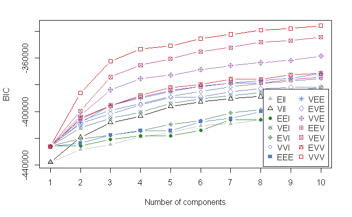

```r
plot(res.mclust,what="BIC")
```

```r
names(res.mclust)
```

```
 [1] "call"           "data"           "modelName"      "n"              "d"              "G"
 [7] "BIC"            "loglik"         "df"             "bic"            "icl"            "hypvol"
[13] "parameters"     "z"              "classification" "uncertainty"
```

```r
table(res.mclust$class,as.vector(y_data[,1]))
```

```
       1  10   2   3   4   5   6   7   8   9
  1  530   0   1  60 367   1 239 162   1  75
  2    1 186   2   3   0 420   3   1  58  12
  3  773   0   0   9   1   0  11  92   0   1
  4    5  54  24  28 158   8 119   0 301 440
  5    5   3   3 755  16  99   9  21   3  40
  6  208   0   7   1   1  11  20 545   0   7
  7   31  49   1  73 280 137 313  12 225 109
  8    0   0 608   0   0   1   0   0   0   0
  9    0 529  13   0   1 173   2   0 204  23
  10   0   0 610   0   0   2   0   1   0   1
```

```r
res.mclust$modelName
```

```
[1] "VVV"
```

```r
adjustedRandIndex(res.mclust$class,as.vector(y_data[,1]))
```

```
[1] 0.353114
```

```r
set.seed(1)
res.mixmod = mixmodCluster(data=as.data.frame(res.PCA$ind$coord),nbCluster=1:10,models=mixmodGaussianModel(listModels = c("Gaussian_p_Lk_Ck", "Gaussian_pk_Lk_Ck", "Gaussian_pk_Lk_Dk_A_Dk", "Gaussian_p_Lk_Dk_A_Dk")))
#
#res.mixmod
summary(res.mixmod)
```

```
* Number of samples    =  9298
* Problem dimension    =  8
*       Number of cluster =  10
*              Model Type =  Gaussian_pk_Lk_Ck
*               Criterion =  BIC(334746.6425)
*              Parameters =  list by cluster
*                  Cluster  1 :
                         Proportion =  0.1204
                              Means =  -9.7315 -2.7885 -3.9488 0.6245 0.7690 3.6425 -0.9860 0.1651
                          Variances = |     0.0888    -0.1260     0.2657     0.0230     0.2134     0.2065    -0.0001     0.0643 |
                                      |    -0.1260     0.5762    -0.9976    -0.2016    -1.1710    -1.0263    -0.1094    -0.5113 |
                                      |     0.2657    -0.9976     2.6852     0.7425     3.0638     2.4729     0.8389     0.9511 |
                                      |     0.0230    -0.2016     0.7425     0.3181     0.9286     0.7189     0.3597     0.1880 |
                                      |     0.2134    -1.1710     3.0638     0.9286     3.7532     2.8835     1.0255     1.1523 |
                                      |     0.2065    -1.0263     2.4729     0.7189     2.8835     2.5319     0.7096     0.9229 |
                                      |    -0.0001    -0.1094     0.8389     0.3597     1.0255     0.7096     0.5485     0.2097 |
                                      |     0.0643    -0.5113     0.9511     0.1880     1.1523     0.9229     0.2097     0.6222 |
*                  Cluster  2 :
                         Proportion =  0.1130
                              Means =  -0.9950 7.9893 0.1438 -2.2380 1.6889 -1.6288 -0.7922 1.1689
                          Variances = |     7.5251     6.9187     0.7247    -1.5637     3.8330     2.1616    -4.3545     2.1434 |
                                      |     6.9187    28.2252     0.9182     9.0040     3.1257     8.4842   -16.2149    -1.1434 |
                                      |     0.7247     0.9182    12.8647     2.1581    -0.6375     3.1919     5.1020    -0.7407 |
                                      |    -1.5637     9.0040     2.1581    13.2455     1.9358     7.6049    -7.6950    -6.3031 |
                                      |     3.8330     3.1257    -0.6375     1.9358    12.2434     4.2869    -1.3970     1.2063 |
                                      |     2.1616     8.4842     3.1919     7.6049     4.2869    12.2589    -3.6751    -2.9558 |
                                      |    -4.3545   -16.2149     5.1020    -7.6950    -1.3970    -3.6751    20.4167     0.5378 |
                                      |     2.1434    -1.1434    -0.7407    -6.3031     1.2063    -2.9558     0.5378     7.5002 |
*                  Cluster  3 :
                         Proportion =  0.0607
                              Means =  -1.4677 -6.4974 1.0655 -2.0446 1.1006 -2.2550 -4.8258 -0.6533
                          Variances = |     9.3673    -3.9105     3.1190     0.3420     0.0807    -1.3466    -0.4906     0.0501 |
                                      |    -3.9105     3.2195    -2.8039    -0.7113    -1.8224    -0.6950     0.9726    -1.5299 |
                                      |     3.1190    -2.8039     4.6995    -0.3466     3.7640     0.8272    -0.6959     1.6026 |
                                      |     0.3420    -0.7113    -0.3466     1.2424    -0.2074     0.2720    -0.2228     0.6461 |
                                      |     0.0807    -1.8224     3.7640    -0.2074     6.4719     1.1363    -0.0645     0.9763 |
                                      |    -1.3466    -0.6950     0.8272     0.2720     1.1363     2.5638    -0.4482     1.4146 |
                                      |    -0.4906     0.9726    -0.6959    -0.2228    -0.0645    -0.4482     0.8798    -0.2983 |
                                      |     0.0501    -1.5299     1.6026     0.6461     0.9763     1.4146    -0.2983     3.6870 |
*                  Cluster  4 :
```

[output cut: 62 more lines]

```
                                      |     0.8068    -0.2566     2.9729     1.3636     1.7451     4.0188     1.1174     0.4617 |
                                      |    -0.1982     2.7242     2.1428     1.3106     3.0410     1.1174     3.8170    -1.3614 |
                                      |     1.4900    -3.0650     0.8644    -1.7256    -1.2362     0.4617    -1.3614     6.5211 |
*                  Cluster  10 :
                         Proportion =  0.0832
                              Means =  5.9921 -4.4019 3.6754 -3.7941 -0.9051 -1.2826 -0.8324 -2.5432
                          Variances = |    18.0227    -2.0182     1.6045    -1.2018     2.0012     4.6285     3.2835     0.0845 |
                                      |    -2.0182     5.3246    -2.0029    -0.6696    -3.1906    -1.0243     0.7551    -3.4600 |
                                      |     1.6045    -2.0029    13.2040    -3.1333     8.3995     2.2325     1.5008     2.9232 |
                                      |    -1.2018    -0.6696    -3.1333     2.4797    -0.9199    -0.7607    -0.5871    -0.2314 |
                                      |     2.0012    -3.1906     8.3995    -0.9199    12.4063     1.0385     1.3358     1.7725 |
                                      |     4.6285    -1.0243     2.2325    -0.7607     1.0385     3.0359     1.2642     1.3545 |
                                      |     3.2835     0.7551     1.5008    -0.5871     1.3358     1.2642     1.8786    -0.0862 |
                                      |     0.0845    -3.4600     2.9232    -0.2314     1.7725     1.3545    -0.0862     5.8775 |
*          Log-likelihood =  -165321.9402
```

```r
predictions= mixmodPredict(as.data.frame(res.PCA$ind$coord), classificationRule=res.mixmod["bestResult"])
```

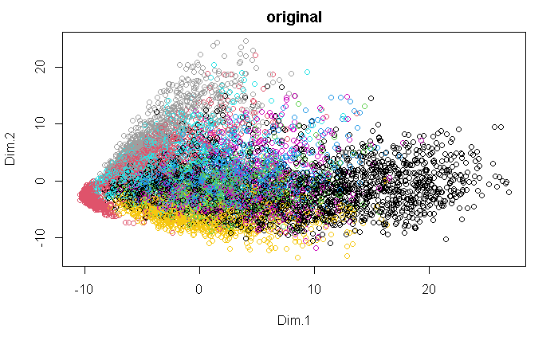

```r
pred.rmix = as.vector(predictions["partition"])
pred.mclust = as.vector(res.mclust$class)
true_values = as.vector(y_data[,1])

plot(res.PCA$ind$coord,col=true_values, main = "original")
```

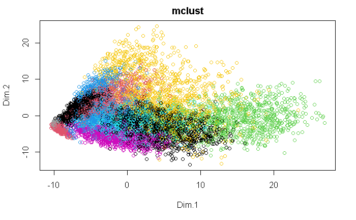

```r
plot(res.PCA$ind$coord,col=pred.mclust, main = "mclust")
```

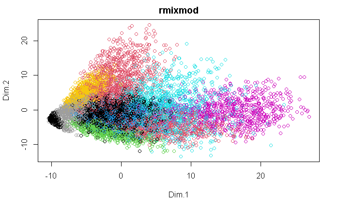

```r
plot(res.PCA$ind$coord,col=pred.rmix, main = "rmixmod")
```

# Q8 : comparer les partitions de mclust et rmixmod

Les resultats des deux packages sont cette fois-ci tres different, on remarque que à part pour le cluster 8 de mclust qui semble avoir été englobé dans le cluster 1 rmixmod le reste des clusters semblent tres differents.

```r
table(pred.rmix,pred.mclust)
```

```
         pred.mclust
pred.rmix   1   2   3   4   5   6   7   8   9  10
       1    0   0   0   0   0   0   0 609   0 509
       2    0 443   0 140  45   0 418   0   3   0
       3   51   0   0   0   0 518   0   0   0   0
       4    1   7   0   1 748   0   2   0   0   0
       5  145   4  92   5  78   0 786   0   0   0
       6   16   0 739   0   0   0   0   0   0   0
       7    0  62   0 247   0   0   0   0 529   0
       8    0 164   0 172   6  24   0   0 413 105
       9  662   6   0 570  75  96  24   0   0   0
       10 561   0  56   2   2 162   0   0   0   0
```

# Q9: MclustDR

MclustDR est une methode de reduction de la dimension linéaire utilisé afin de visualiser le resultat de clustering ou de classification obtenue par des mélanges gaussiens.

```r
res.mclustdr = MclustDR(res.mclust)
summary(res.mclustdr)
```

```
-----------------------------------------------------------------
Dimension reduction for model-based clustering and classification
-----------------------------------------------------------------

Mixture model type: Mclust (VVV, 10)

Clusters    n
      1  1436
      2   686
      3   887
      4  1137
      5   954
      6   800
      7  1230
      8   609
      9   945
      10  614

Estimated basis vectors:
           Dir1      Dir2      Dir3     Dir4        Dir5      Dir6      Dir7       Dir8
Dim.1 -0.073011 -0.025939 -0.759077  0.18217 -0.09177707 -0.026207 -0.030699  0.0691346
Dim.2  0.442073 -0.069197 -0.271956 -0.36924 -0.00015151 -0.198112 -0.385960 -0.0029229
Dim.3 -0.048628 -0.374946  0.443025  0.17605 -0.36677407 -0.252478 -0.118819  0.4960379
Dim.4 -0.282916 -0.747312 -0.210546 -0.34201  0.27846212  0.173839  0.077660 -0.0317927
Dim.5  0.463283  0.037370 -0.152353 -0.15386 -0.12256288  0.596414  0.315370  0.4971129
Dim.6  0.078086  0.123237 -0.012432  0.23948  0.86134186 -0.237016 -0.021980  0.5415989
Dim.7 -0.635874  0.408660  0.047474 -0.33553 -0.02956943  0.399501 -0.631587  0.3600914
Dim.8 -0.302937  0.334503 -0.289174 -0.69922 -0.14733218 -0.542782  0.575412  0.2793405

               Dir1     Dir2     Dir3    Dir4     Dir5    Dir6     Dir7      Dir8
Eigenvalues  1.8999  0.93315  0.79257  0.6487  0.58058  0.5087  0.41632   0.16673
Cum. %      31.9495 47.64147 60.96940 71.8780 81.64106 90.1954 97.19623 100.00000
```

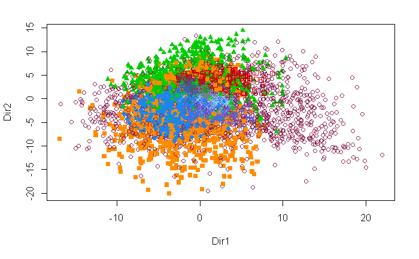

```r
plot(res.mclustdr, what="scatterplot")
```

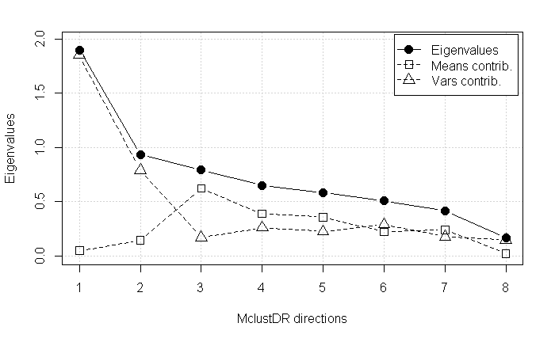

```r
plot(res.mclustdr, what="evalues")
```

# Q10: Comparaison des different algorithmes

D’apres les resultats obtenu, on remarque que le nombre de cluster optimal est bel et bien 10, aussi, rmixmod semble obtenir les meilleurs resultats sur l’ensemble des methodes, les methodes de melanges en general semble obtenir de bien meilleurs resultats comparé aux algorithmes de clustering standard.

Si nous comparons Mclust à Rmixmod, on voit que rmixmod semble plus performant sur ce dataset, cependant, il dépasse mclust de peu et reste instable et requiert plusieurs test afin de fonctionner convenablement.

Mclust semble aussi plus rapide, ceci peut étre expliquer par le fait que les deux méthodes utilises de initialisations differente au lancement de leurs algorithmes (cah pour mclust, et un smallEM pour rmixmod), la methode d’initialisation de mclust semble plus rapide et donner de meilleurs resultats en moyenne.

Rmixmod semble plus performant lorsque que l’on a plus de données (l’initialisation smallEM semble devenir plus efficace)

```r
library(clusterSim)
library(aricode)

pred.rmix = as.vector(predictions["partition"])
pred.mclust = as.vector(res.mclust$class)
true_values = as.vector(y_data[,1])


print(paste("Rmixmod taux de mal classé : ", 1- comparing.Partitions(pred.rmix,true_values)))
```

```
[1] "Rmixmod taux de mal classé :  0.502277725929532"
```

```r
print(paste("Mclust taux de mal classé : ", 1-comparing.Partitions(pred.mclust,true_values)))
```

```
[1] "Mclust taux de mal classé :  0.521212989844174"
```

```r
print(paste("cah ward taux de mal classé : ", 1-comparing.Partitions(res_cah_ward$Best.partition,true_values)))
```

```
[1] "cah ward taux de mal classé :  0.764545134834039"
```

```r
print(paste("cah average taux de mal classé : ", 1-comparing.Partitions(res_cah_average$Best.partition,true_values)))
```

```
[1] "cah average taux de mal classé :  0.857433437751663"
```

```r
print(paste("cah complete de mal classé : ", 1-comparing.Partitions(res_cah_complete$Best.partition,true_values)))
```

```
[1] "cah complete de mal classé :  0.81632260774803"
```

```r
print(paste("cah singe  taux de mal classé : ", 1-comparing.Partitions(res_cah_single$Best.partition,true_values)))
```

```
[1] "cah singe  taux de mal classé :  0.926689354173353"
```

```r
print(paste("kmeans  taux de mal classé : ", 1-comparing.Partitions(res_cah_kmeans$Best.partition,true_values)))
```

```
[1] "kmeans  taux de mal classé :  0.808655728263364"
```

```r
print("")
```

```
[1] ""
```

```r
print("")
```

```
[1] ""
```

```r
print(paste("Rmixmod ARI : ",adjustedRandIndex(pred.rmix,true_values)))
```

```
[1] "Rmixmod ARI :  0.430017593959761"
```

```r
(paste("Mclust ARI : ",adjustedRandIndex(pred.mclust,true_values)))
```

```
[1] "Mclust ARI :  0.353114028584421"
```

```r
print(paste("cah_ward ARI : ",adjustedRandIndex(res_cah_ward$Best.partition,true_values)))
```

```
[1] "cah_ward ARI :  0.0500092315321071"
```

```r
(paste("cah_average ARI : ",adjustedRandIndex(res_cah_average$Best.partition,true_values)))
```

```
[1] "cah_average ARI :  0.00947648567705501"
```

```r
(paste("cah_complete ARI : ",adjustedRandIndex(res_cah_complete$Best.partition,true_values)))
```

```
[1] "cah_complete ARI :  0.10007218286704"
```

```r
(paste("cah_single ARI : ",adjustedRandIndex(res_cah_single$Best.partition,true_values)))
```

```
[1] "cah_single ARI :  3.55204331403028e-05"
```

```r
(paste("kmeans ARI : ",adjustedRandIndex(res_cah_kmeans$Best.partition,true_values)))
```

```
[1] "kmeans ARI :  0.11656577183072"
```

```r
print("")
```

```
[1] ""
```

```r
print("")
```

```
[1] ""
```

```r
print(paste("Rmixmod NMI : ",NMI(pred.rmix,true_values)))
```

```
[1] "Rmixmod NMI :  0.573780719847855"
```

```r
(paste("Mclust NMI : ",NMI(pred.mclust,true_values)))
```

```
[1] "Mclust NMI :  0.520685907491352"
```

```r
print(paste("cah_ward NMI : ",NMI(res_cah_ward$Best.partition,true_values)))
```

```
[1] "cah_ward NMI :  0.128216279028878"
```

```r
(paste("cah_average NMI : ",NMI(res_cah_average$Best.partition,true_values)))
```

```
[1] "cah_average NMI :  0.0760169204493251"
```

```r
(paste("cah_complete NMI : ",NMI(res_cah_complete$Best.partition,true_values)))
```

```
[1] "cah_complete NMI :  0.119286107894691"
```

```r
(paste("cah_single NMI : ",NMI(res_cah_single$Best.partition,true_values)))
```

```
[1] "cah_single NMI :  0.0005648199549908"
```

```r
(paste("kmeans NMI : ",NMI(res_cah_kmeans$Best.partition,true_values)))
```

```
[1] "kmeans NMI :  0.141124485012471"
```

# Q11: TSNE

```r
tsne_res <- Rtsne(x_data[,1:256], dims = 2, perplexity=30, verbose=TRUE, max_iter = 2500)
```

[output not shown]

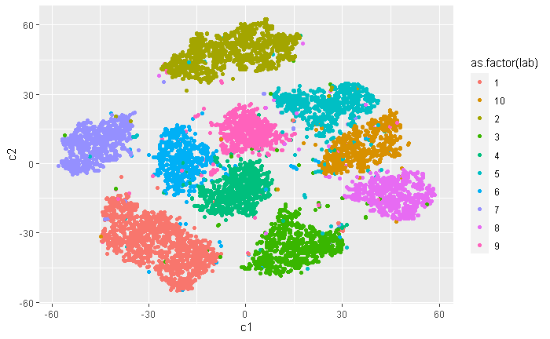

```r
tnse_df = as.data.frame(tsne_res$Y)
tnse_df = cbind(tnse_df,true_values, pred.rmix, pred.mclust)
names(tnse_df) = c("c1", "c2", "lab", "rmix", "mclust")
ggplot(tnse_df, aes(c1, y=c2, color=as.factor(lab)) ) + geom_point()
```

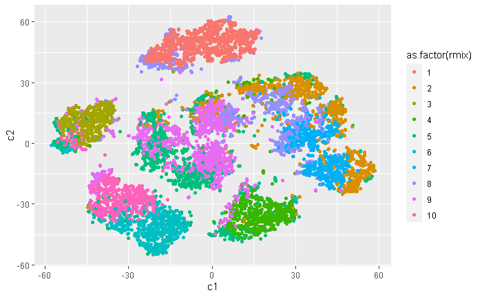

```r
ggplot(tnse_df, aes(c1, y=c2, color=as.factor(rmix)) ) + geom_point()
```

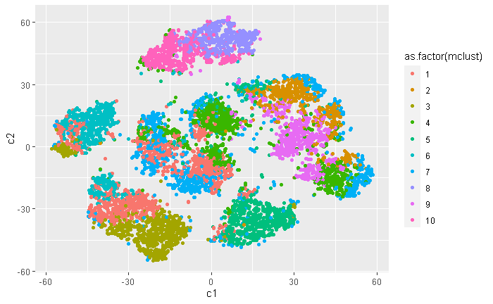

```r
ggplot(tnse_df, aes(c1, y=c2, color=as.factor(mclust))) + geom_point()
```

# Q12 : Reduction par autoencoder

On remarque des resultats legerements superieur pour Rmixmod par rapport à mclust sur l’ensemble des metrics. De maniére plus general la methode de reduction de dimension à l’aide d’auto encoder semble donner de meilleurs résultats et extraire plus d’informations (en particulier des relations non lineaire) que PCA.

```r
h2o.init()
```

[output not shown]

[output not shown]

```r
ae_model <- h2o.deeplearning(x=c(1:256),
                                  model_id="ae_model",
                                  training_frame=as.h2o(x_data[,1:256]),
                                  activation="Tanh",
                                  ignore_const_cols=FALSE,
                                  autoencoder=TRUE,
                                  hidden=c(32,16, 8,16,32),
                                  epochs=75,
                                  reproducible=T,
                                  seed=1)
```

```r
features <- h2o.deepfeatures(ae_model, as.h2o(x_data[,1:256]), layer=3)
```

```r
set.seed(1)
res.mclust=Mclust(features, G = 1:10)
```

```
fitting ...
```

```r
summary(res.mclust$BIC)
```

```
Best BIC values:
           VVV,10     VVV,9     VVV,8
BIC      22869.54 21865.967 20130.670
BIC diff     0.00 -1003.577 -2738.873
```

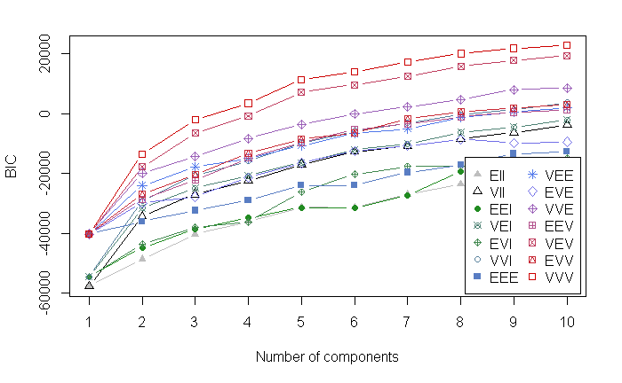

```r
plot(res.mclust,what="BIC")
```

```r
names(res.mclust)
```

```
 [1] "call"           "data"           "modelName"      "n"              "d"              "G"
 [7] "BIC"            "loglik"         "df"             "bic"            "icl"            "hypvol"
[13] "parameters"     "z"              "classification" "uncertainty"
```

```r
table(res.mclust$class,as.vector(y_data[,1]))
```

```
       1  10   2   3   4   5   6   7   8   9
  1  650   0   0   7   1   1   9  14   0   0
  2    1 253  18  16   1 754   3   2 138  38
  3   22  11   6 841  51  86  58  17  13  39
  4   55   8   8  63 770   1 644  34   5 625
  5    1   0   9   2   0   1   1 762   0   3
  6    0 542   8   0   1   5   0   0  16   2
  7  824   0   0   0   0   0   1   4   0   0
  8    0   7   2   0   0   1   0   0 620   1
  9    0   0 631   0   0   1   0   0   0   0
  10   0   0 587   0   0   2   0   1   0   0
```

```r
res.mclust$modelName
```

```
[1] "VVV"
```

```r
adjustedRandIndex(res.mclust$class,as.vector(y_data[,1]))
```

```
[1] 0.5263427
```

```r
res.mixmod = mixmodCluster(data=as.data.frame(features), nbCluster=1:10,models=mixmodGaussianModel(listModels = c("Gaussian_p_Lk_Ck", "Gaussian_pk_Lk_Ck", "Gaussian_pk_Lk_Dk_A_Dk", "Gaussian_p_Lk_Dk_A_Dk")))
```

```r
predictions= mixmodPredict(as.data.frame(features), classificationRule=res.mixmod["bestResult"])
```

```r
pred.rmix = as.vector(predictions["partition"])
pred.mclust = as.vector(res.mclust$class)
true_values = as.vector(y_data[,1])

print(paste("Rmixmod taux de bien classé : ", comparing.Partitions(pred.rmix,true_values)))
```

```
[1] "Rmixmod taux de bien classé :  0.636007065961222"
```

```r
print(paste("Mclust taux de bien classé : ", comparing.Partitions(pred.mclust,true_values)))
```

```
[1] "Mclust taux de bien classé :  0.581086437496352"
```

```r
print(paste("Rmixmod ARI : ",adjustedRandIndex(pred.rmix,true_values)))
```

```
[1] "Rmixmod ARI :  0.582139193509047"
```

```r
(paste("Mclust ARI : ",adjustedRandIndex(pred.mclust,true_values)))
```

```
[1] "Mclust ARI :  0.526342676668219"
```

```r
print(paste("Rmixmod NMI : ",NMI(pred.rmix,true_values)))
```

```
[1] "Rmixmod NMI :  0.704982907142548"
```

```r
(paste("Mclust NMI : ",NMI(pred.mclust,true_values)))
```

```
[1] "Mclust NMI :  0.701578946011471"
```

[output not shown]